# Teste de hipóteses

Larissa Martins Marques

2022-09-12

```r
tema <- ggthemes::theme_fivethirtyeight() +
  theme(legend.title = element_text(family = "Times New Roman"),
        legend.position = "bottom",
        title = element_text(size = 10),
        axis.title.y = element_text(size = 14, family = "Times New Roman"),
        axis.text.y = element_text(size = 20, family = "Times New Roman"),
        axis.text.x = element_text(size = 20, family = "Times New Roman"),
        axis.title.x = element_text(size = 20,family = "Times New Roman"),
        legend.text = element_text(size = 30, family = "Times New Roman"),
        plot.caption = element_text(hjust = 0, size = 24, family = "Times New Roman" ),
        panel.background = element_rect(fill = "white", colour = "white", color = "white"),
        plot.background = element_rect(fill = "white", colour = "white", color = "white"),
        legend.background = element_rect(fill = "white"),
        panel.grid.major.x = element_line(colour = "#eceff2", size = 0.8),
        panel.grid.major.y = element_line(colour = "#eceff2", size = 0.8),
        legend.key = element_rect(fill = "white", color = "white"),
        strip.background = element_rect(fill = "white", colour = "white"),
        strip.text = element_text(size = 29, colour = "black", face = "bold", family = "Times New Roman"))

ggplot2::theme_set(tema)
```

# 1 Considerações iniciais

Os dados utilizados para a execução do teste de hipótese são derivados do *survey* “A cara da democracia” do ano de 2018 e pode ser acessado [aqui](https://www.institutodademocracia.org/a-cara-da-democracia).

A seguir algumas informações sobre os dados

```r
tabela_1 <- data_2018_a %>%
  filter(interesse <=4) %>%
  select(interesse, sexo) %>%
  group_by(sexo, interesse) %>%
  summarise(Total_casos_sexo_interesse = n()) %>%
  ungroup() %>%
  mutate(N = sum(Total_casos_sexo_interesse),
         sexo = case_when(sexo == 1 ~ "Homem",
                          sexo == 2 ~ "Mulher"),
          interesse= case_when(interesse== 1 ~ "Muito interessado",
                                                 interesse== 2 ~ "Interessado",
                                                 interesse== 3 ~ "Pouco interessado",
                                                 interesse== 4 ~ "Nada Interessado"))
tabela_1 %>%
  kbl() %>%
  kable_material(c("striped"))
```

| sexo | interesse | Total_casos_sexo_interesse | N |
| --- | --- | --- | --- |
| Homem | Muito interessado | 88 | 2459 |
| Homem | Interessado | 185 | 2459 |
| Homem | Pouco interessado | 515 | 2459 |
| Homem | Nada Interessado | 396 | 2459 |
| Mulher | Muito interessado | 46 | 2459 |
| Mulher | Interessado | 113 | 2459 |
| Mulher | Pouco interessado | 493 | 2459 |
| Mulher | Nada Interessado | 623 | 2459 |

A pergunta é feita da seguinte maneira:

Quanto o(a) sr(a) se interessa por política? O(a) sr(a) diria que é:

1. Muito interessado,
2. Interessado,
3. Pouco interessado, ou
4. Nada Interessado.

No presente trabalho, para fins metodológicos as categorias (1-4) são tratas como númericas.

## 1.1 A hipótese a ser testada:

```
H1: mulheres manifestam menor interesse por política.
```

# 2 Teste de hipóteses

## 2.1 A distribuição

Linhas verticais representam as médias dos grupos

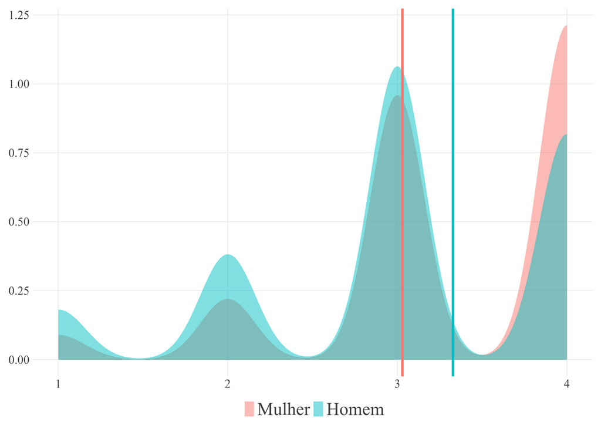

```r
data_2018_interesse <- data_2018_a %>%
  drop_na(c(interesse, sexo)) %>% # retira os NA
  filter(interesse<=4,
         sexo %in% c(1,2)) # filtra apenas os valores de interesse


data_2018_interesse %>%
  mutate(sexo = case_when(sexo == 1 ~ "Homem",
                          sexo == 2 ~ "Mulher")) %>% # altera rótulo das variáveis
    ggplot(aes(x=interesse, fill = as_factor(sexo), col = as_factor(sexo), group = as_factor(sexo)))+
  geom_density(color=NA, alpha = 0.5)+
  geom_vline(data=. %>% group_by(sexo) %>% summarise(media=mean(interesse,na.rm = T)),
             size=2, aes(xintercept=media,color=sexo), show.legend = F) +
  scale_x_continuous(breaks = c(1:10))+

  labs(x= NULL, y=NULL, fill = NULL, col = NULL, group = NULL)+ tema
```

## 2.2 Os pressupostos

### 2.2.1 Normalidade dos dados

H0: distribuição dos dados = normal -> p > 0.05

H1: distribuição dos dados != normal -> p <= 0.05

```r
data_2018_interesse %>%
  shapiro_test(interesse,sexo)
```

```
## # A tibble: 2 × 3
##   variable  statistic        p
##   <chr>         <dbl>    <dbl>
## 1 interesse     0.800 5.88e-48
## 2 sexo          0.636 3.93e-58
```

O teste de normalidade conduziu a rejeição da hipótese nula, ou seja, a distribuição dos dados não é normal.

### 2.2.2 Homogeneidade das Variâncias

H0: as variâncias dos grupos são homogêneas -> p > 0.05

H1: as variâncias dos grupos não são homogêneas -> p <= 0.05

```r
car::leveneTest(y = data_2018_interesse$interesse,
  group = data_2018_interesse$sexo)
```

```
## Levene's Test for Homogeneity of Variance (center = median)
##         Df F value Pr(>F)
## group    1  0.1834 0.6685
##       2457
```

O teste de homogeneidade de variânicas conduziu ao aceite da hipótese nula, ou seja, as variâncias dos dados analisados sãos homogêneas.

A escolha do teste adequado foi realizada de acordo com a análise dos pressupostos. Como o pressuposto de normalidade da distribuição dos dados não pode ser atendido, a maneira tradicional e conservadora exigiria que se realizasse um teste não paramétrico. Porém, foi realizado um Teste T com o pacote *infer* que realiza as devidas correções de maneira automática quando não se atende aos pressupostos.

### 2.2.3 O teste da hipótese

```r
data_2018_interesse %>%
infer::t_test(formula = interesse ~ sexo, var.equal = TRUE)
```

```
## # A tibble: 1 × 7
##   statistic  t_df  p_value alternative estimate lower_ci upper_ci
##       <dbl> <dbl>    <dbl> <chr>          <dbl>    <dbl>    <dbl>
## 1     -8.85  2457 1.69e-18 two.sided     -0.298   -0.364   -0.232
```

Pode-se dizer que a média de interesse por política de homens e mulheres é diferente.

## 2.3 As fragilidades do teste:

O teste de médias dos grupos não apresenta uma relação de causalidade visto que nao é possivel observar todas as variáveis que podem interferir entre interesse por política e gênero.